# All plots examples

## 2 Hazard ratio plots

### 2.01 Standard hazard ratio plot

This is used to visually present the results from a multivariable Cox Proportional Hazards model.

Here is the model:

```r
library(finalfit)
explanatory = c("age.factor", "sex.factor", "obstruct.factor", "perfor.factor")
dependent = "Surv(time, status)"
colon_s %>%
  finalfit(dependent, explanatory) %>%
    knitr::kable(row.names=FALSE) # This line only needed for formatting.
```

| Dependent: Surv(time, status) |  | all | HR (univariable) | HR (multivariable) |
| --- | --- | --- | --- | --- |
| Age | <40 years | 70 (7.5) | - | - |
|  | 40-59 years | 344 (37.0) | 0.76 (0.53-1.09, p=0.132) | 0.79 (0.55-1.13, p=0.196) |
|  | 60+ years | 515 (55.4) | 0.93 (0.66-1.31, p=0.668) | 0.98 (0.69-1.40, p=0.926) |
| Sex | Female | 445 (47.9) | - | - |
|  | Male | 484 (52.1) | 1.01 (0.84-1.22, p=0.888) | 1.02 (0.85-1.23, p=0.812) |
| Obstruction | No | 732 (80.6) | - | - |
|  | Yes | 176 (19.4) | 1.29 (1.03-1.62, p=0.028) | 1.30 (1.03-1.64, p=0.026) |
| Perforation | No | 902 (97.1) | - | - |
|  | Yes | 27 (2.9) | 1.17 (0.70-1.95, p=0.556) | 1.08 (0.64-1.81, p=0.785) |

Simply switch to `hr_plot()` for plot.

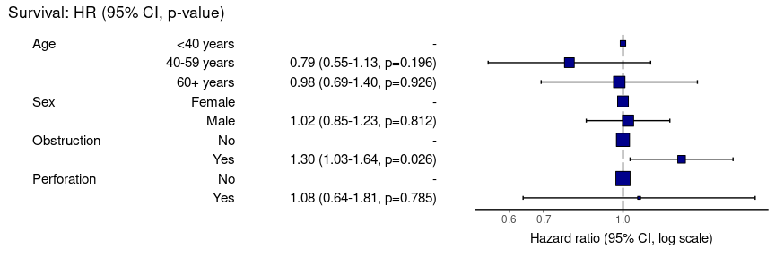

```r
library(finalfit)
explanatory = c("age.factor", "sex.factor", "obstruct.factor", "perfor.factor")
dependent = "Surv(time, status)"
colon_s %>%
  hr_plot(dependent, explanatory)
```

```r
# Note this example uses fig.height=3, fig.width=9
```

- All options list for odds ratio plots above (section 1) apply to hazard ratio plots.

## 3 Coefficient plots

### 3.01 Standard coefficient plots

This is used to visually present the results from a multivariable linear regression model.

Here is the model:

```r
library(finalfit)
explanatory = c("age.factor", "sex.factor", "obstruct.factor", "perfor.factor")
dependent = "nodes"
colon_s %>%
  finalfit(dependent, explanatory) %>%
    knitr::kable(row.names=FALSE) # This line only needed for formatting.
```

| Dependent: nodes |  | unit | value | Coefficient (univariable) | Coefficient (multivariable) |
| --- | --- | --- | --- | --- | --- |
| Age | <40 years | Mean (sd) | 4.7 (4.5) | - | - |
|  | 40-59 years | Mean (sd) | 3.6 (3.3) | -1.14 (-2.08 to -0.21, p=0.016) | -1.21 (-2.16 to -0.26, p=0.012) |
|  | 60+ years | Mean (sd) | 3.6 (3.6) | -1.19 (-2.10 to -0.28, p=0.010) | -1.25 (-2.18 to -0.33, p=0.008) |
| Sex | Female | Mean (sd) | 3.7 (3.6) | - | - |
|  | Male | Mean (sd) | 3.6 (3.6) | -0.14 (-0.60 to 0.33, p=0.565) | -0.07 (-0.54 to 0.40, p=0.779) |
| Obstruction | No | Mean (sd) | 3.7 (3.7) | - | - |
|  | Yes | Mean (sd) | 3.5 (3.2) | -0.24 (-0.83 to 0.36, p=0.435) | -0.31 (-0.91 to 0.29, p=0.313) |
| Perforation | No | Mean (sd) | 3.7 (3.6) | - | - |
|  | Yes | Mean (sd) | 3.9 (2.8) | 0.24 (-1.13 to 1.61, p=0.735) | 0.28 (-1.09 to 1.66, p=0.686) |

Simply switch to `coeffcient_plot()` for plot.

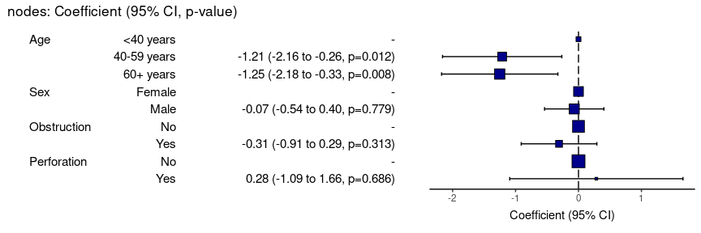

```r
library(finalfit)
explanatory = c("age.factor", "sex.factor", "obstruct.factor", "perfor.factor")
dependent = "nodes"
colon_s %>%
  coefficient_plot(dependent, explanatory)
```

```r
# Note this example uses fig.height=3, fig.width=9
```

- All options list for odds ratio plots above (section 1) apply to coefficient ratio plots.

## 4 Wrapper for all plot types

`ff_plot()` will automatically determine the dependent variable type (binary, survival object, or continuous), and produce the appropriate output (odds ratio, hazard ratio, or coefficient plot).

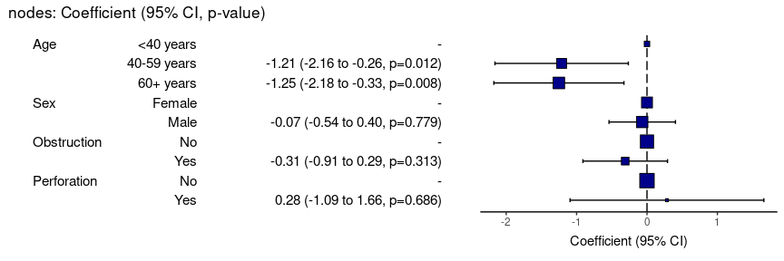

```r
library(finalfit)
explanatory = c("age.factor", "sex.factor", "obstruct.factor", "perfor.factor")
dependent = "nodes"
colon_s %>%
  ff_plot(dependent, explanatory)
```

```r
# Note this example uses fig.height=3, fig.width=9
```

## 5 Kaplan Meier plots

Use finalfit grammar to plot a survival curve with number-at-risk table using `survminer::ggsurvplot()`.

### 5.1 Standard KM plot

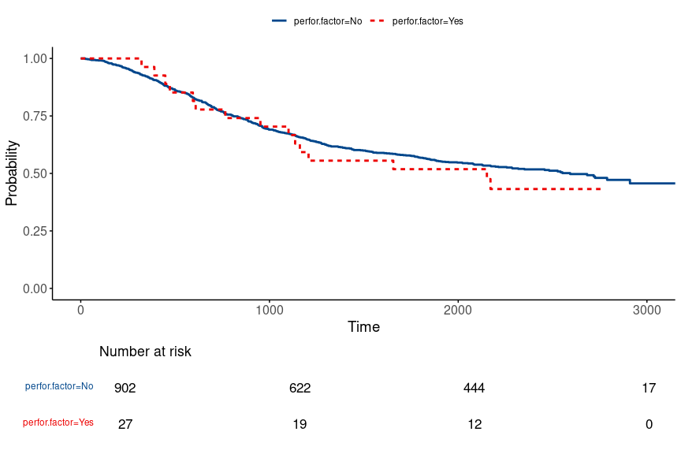

```r
library(finalfit)
explanatory = "perfor.factor"
dependent = "Surv(time, status)"
colon_s %>%
    surv_plot(dependent, explanatory)
```

### 5.2 Adjust using options

Pass any of the options from `survminer::ggsurvplot()`.

For example:

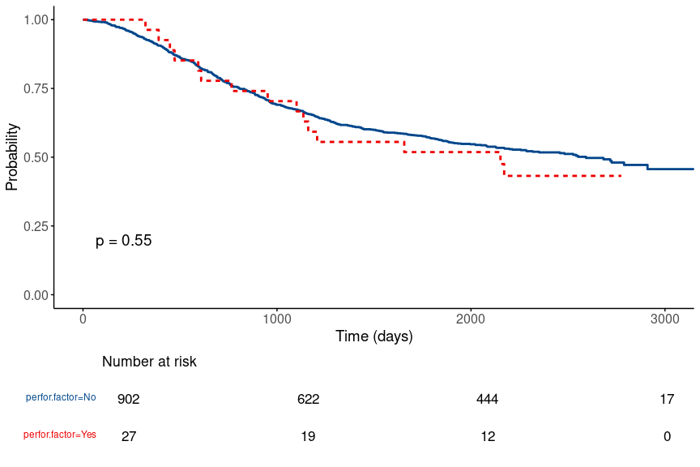

```r
library(finalfit)
explanatory = "perfor.factor"
dependent = "Surv(time, status)"
colon_s %>%
    surv_plot(dependent, explanatory, xlab="Time (days)", pval=TRUE, legend="none")
```

## 6 Missing data plots

See https://finalfit.org/articles/missing.html